# Regression Linéaire

S. Jaubert

10 avril 2020

# Rappel sur le modèle linéaire simple

**la régression linéaire simple est une méthode statistique classique, qui est employée pour évaluer la significativité du lien linéaire entre deux variables numériques continues.**

**Exemple :** Une machine produit automatiquement des pièces cylindriques. Réglée initialement pour un diamètre de 8 mm, elle se dérègle en cours d’utilisation. Afin de contrôler la fabrication et de procéder aux réglages éventuellement nécessaires, on mesure le diamètre de la dernière pièce dans chaque série de dix pièces produites. Les résultats sont les suivants :

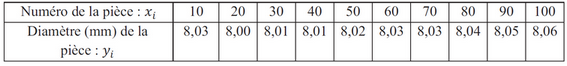

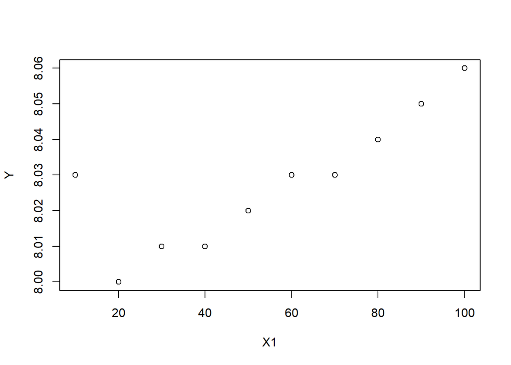

```r
X1<-seq(10,100,10)
Y<-c(8.03,8,8.01,8.01,8.02,8.03,8.03,8.04,8.05,8.06)
plot(x = X1,y = Y)
```

Le modèle linéaire est visiblement le plus approprié :

$Y_{i}=aX1_{i}+b+\epsilon_{i}$ où chaque $\epsilon_{i}$ est un terme résiduel aléatoire suivant la loi normale $N(0,\sigma^{2})$ (on dit que les $\epsilon_{i}$ sont des variables iid) a et b sont des paramètres inconnus.

L’idée est de minimiser (méthode des moindres carrés) la somme des $\epsilon_{i}^{2}$ :

$$\sum_{i=1}^{n} \epsilon_{i}^{2}=\sum_{i=1}^{n}(Y_{i}-(aX1_{i}+b))^{2}$$
avec $Y=(Y_{1},Y_{2},...,Y_{n})$ et $X1=(X1_{1},X1_{2},...,X1_{n})$

Où Y et X1 sont les vecteurs de nos données observées

Le plus simple est de construire un système matriciel :

```r
(X<-matrix(cbind(rep(1,length(X1)),X1),ncol=2) )
```

```
##       [,1] [,2]
##  [1,]    1   10
##  [2,]    1   20
##  [3,]    1   30
##  [4,]    1   40
##  [5,]    1   50
##  [6,]    1   60
##  [7,]    1   70
##  [8,]    1   80
##  [9,]    1   90
## [10,]    1  100
```

```r
(Y<-matrix(Y,ncol=1))
```

```
##       [,1]
##  [1,] 8.03
##  [2,] 8.00
##  [3,] 8.01
##  [4,] 8.01
##  [5,] 8.02
##  [6,] 8.03
##  [7,] 8.03
##  [8,] 8.04
##  [9,] 8.05
## [10,] 8.06
```

On peut alors écrire :

$Y=X\beta+\epsilon$ où $\beta$ est la matrice (2,1) : $\begin{pmatrix}b\\a\end{pmatrix}$ On a :

$\epsilon=Y-X\beta$ et [on démontre](https://fr.wikipedia.org/wiki/R%C3%A9gression_lin%C3%A9aire_multiple#La_m%C3%A9thode_des_moindres_carr%C3%A9s_ordinaires) que l’estimateur de $\beta$ est :

$\hat{\beta} = (X'X)^{-1}X'Y$ ($X'$ représente la transposée de $X$)

Effectuons les calculs avec **R** :

```r
(beta<-solve(t(X)%*%X)%*%t(X)%*%Y)
```

```
##              [,1]
## [1,] 8.0000000000
## [2,] 0.0005090909
```

Nous pouvons calculer à présent le vecteur $\hat{Y}$ prédit par notre modèle :

```r
Y_hat<-X%*%beta
```

puis la somme des carrés des résidus :

```r
 (Scres<-sum((Y-Y_hat)^{2}))
```

```
## [1] 0.001021818
```

Nous verrons plus loin que **l’estimateur sans biais de $\sigma^{2}$ est donné par $CMres=\frac{Scres}{n-p}$** (ici n=10 et p=2, n-p est le nombre de ddl associé à Scres)

```r
n<-10 #nombre de lignes de la matrice X
p<-2  #   "   " colonnes "  "    "    X
```

Soit :

```r
(CMres<-Scres/(n-p))
```

```
## [1] 0.0001277273
```

**La somme des carrés expliqués par la régression :**

```r
 (Screg<-sum((Y_hat-mean(Y))^{2}))
```

```
## [1] 0.002138182
```

```r
CMreg<-Screg/(p-1)
```

Retrouvons avec **R** les valeurs critiques permettant la prise de décision (Test de Fisher) :

```r
(Fobs<-CMreg/CMres)
```

```
## [1] 16.74021
```

```r
(Fth<-qf(p = 1-0.05,df1 = p-1,df2 = n-p))
```

```
## [1] 5.317655
```

```r
pf(Fobs,df1 = p-1,df2 = n-p,lower.tail = F)
```

```
## [1] 0.003478466
```

$F_{obs}$ est bien supérieur au $F_{th}$, on rejette donc l’hypothèse nulle $H_{0} : \beta_{1}=0$

Pour rappel (voir cours sur l’ANOVA) :

$\begin{matrix}\sum_{i}(Y_{i}-\bar{Y})^{2} &=&\sum_{i}(Y_{i}-\hat{Y_{i}})^{2} &+& \sum_{i} (\hat{Y_{i}}-\bar{Y})^{2} \\ SCT &=& SCres &+& SCreg \\ \end{matrix}$

La capacité du modèle à expliquer les variations de Y est donné par le fameux $R^{2}=\frac{Screg}{Screg+Scres}$ **(c’est le pourcentage de Y qui est expliqué par la régression)**

Soit ici :

```r
(R2<-Screg/(Screg+Scres))
```

```
## [1] 0.6766398
```

Sous **R** il est très facile d’obtenir tous ces résultats très simplement avec l’instruction *lm* :

```r
(model<-lm(Y~X1))
```

```
##
## Call:
## lm(formula = Y ~ X1)
##
## Coefficients:
## (Intercept)           X1
##   8.0000000    0.0005091
```

Les coefficients de notre modèle sont donnés avec :

```r
coefficients(model)
```

```
##  (Intercept)           X1
## 8.0000000000 0.0005090909
```

le vecteur $\hat{Y}$ prédit par notre modèle sera donné par :

```r
fitted.values(model)
```

```
##        1        2        3        4        5        6        7        8
## 8.005091 8.010182 8.015273 8.020364 8.025455 8.030545 8.035636 8.040727
##        9       10
## 8.045818 8.050909
```

et la SCres est obtenue très simplement par :

```r
sum(residuals(model)^2)
```

```
## [1] 0.001021818
```

Que l’on retrouve aussi par une ANOVA classique :

```r
anova(model)
```

```
## Analysis of Variance Table
##
## Response: Y
##           Df    Sum Sq    Mean Sq F value   Pr(>F)
## X1         1 0.0021382 0.00213818   16.74 0.003478 **
## Residuals  8 0.0010218 0.00012773
## ---
## Signif. codes:  0 '***' 0.001 '**' 0.01 '*' 0.05 '.' 0.1 ' ' 1
```

**Donnons un peu plus d’explications sur les résultats fournis par le** *summary(model)* :

```r
summary(model)
```

```
##
## Call:
## lm(formula = Y ~ X1)
##
## Residuals:
##       Min        1Q    Median        3Q       Max
## -0.010364 -0.005591 -0.003000  0.003000  0.024909
##
## Coefficients:
##              Estimate Std. Error  t value Pr(>|t|)
## (Intercept) 8.0000000  0.0077205 1036.203  < 2e-16 ***
## X1          0.0005091  0.0001244    4.091  0.00348 **
## ---
## Signif. codes:  0 '***' 0.001 '**' 0.01 '*' 0.05 '.' 0.1 ' ' 1
##
## Residual standard error: 0.0113 on 8 degrees of freedom
## Multiple R-squared:  0.6766, Adjusted R-squared:  0.6362
## F-statistic: 16.74 on 1 and 8 DF,  p-value: 0.003478
```

**Ligne *(Intercept)* :** nous avons le premier coefficient de notre modèle :8.00000 puis son écart-type 0.0077205 et enfin la t value pour le test de Student de nullité des coefficients, donnée par 8/0.0077205 = 1036.203. Ici la probabilité que le hasard puisse expliquer cette valeur est très faible 2e-16, on rejette donc l’hypothèse de nullité de ce coefficient

**Ligne *X1* :** Nous avons le coefficient directeur de notre modèle : 0.0005091, son écart-type et la t-value, comme précédemment on rejettera donc l’hypothèse de nullité de ce coefficient

**Les codes** ‘***’ ‘**’ ‘*’ nous donne le risque $\alpha$ de 1ère espèce de rejeter l’hypothèse de nullité des coefficients.

**Residual standard error** : est l’écart-type résiduel $\sigma_{X}=\sqrt{CMres}$

```r
CMres<-Scres/(n-p)
sqrt(CMres)
```

```
## [1] 0.01130165
```

**Multiple R-squared** : est le fameux $R^{2}=\frac{Screg}{Screg+Scres}$ que nous avions déjà calculé plus haut par :

```r
(R2<-Screg/(Screg+Scres))
```

```
## [1] 0.6766398
```

**F-statistic** : Nous donne la F-value du test de Fisher de significativité de notre modèle. Que nous avions obtenu aussi par une ANOVA ou par :

```r
(Fobs<-CMreg/CMres)
```

```
## [1] 16.74021
```

Traçons à présent la droite prédite par le modèle :

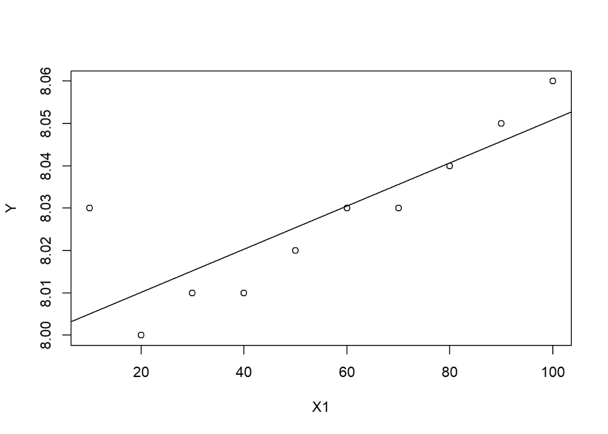

```r
plot(x = X1,y = Y,type="p")
abline(model)
```

# Cas du modèle multiple linéaire (on se restreint au cas où le nombre d’observations est supérieur au nombre de caractéristiques)

**Un exemple :** En fonction des paramètres de coupe : V (vitesse de coupe m/min), f (avance mm/rev), D (profondeur de coupe mm) nous obtenons une rugosité Ra (µm) et des vibrations radiales Ve (mm/s)

Pouvons nous modéliser par une régression linéaire la réponse Ra ou Ve en fonction de V, f et D ?

Commençons par entrer les données (téléchargeables ici : https://sjaubert.github.io/SPCR/rugo_vib.csv)

```r
setwd("D:/OneDrive - CFAI Centre/Bachelor/Regression-Analysis-with-R-master") #à adapter
donnees<-read.csv2("rugo_vib.csv")
donnees
```

```
##       D   V    f   Ra   Ve
## 1  0.15 140 0.08 0.87 0.20
## 2  0.15 140 0.16 1.37 0.21
## 3  0.15 140 0.22 1.98 0.24
## 4  0.15 210 0.08 1.24 0.37
## 5  0.15 210 0.16 1.29 0.41
## 6  0.15 210 0.22 1.82 0.50
## 7  0.15 280 0.08 1.03 0.50
## 8  0.15 280 0.16 1.18 0.52
## 9  0.15 280 0.22 1.87 0.55
## 10 0.33 140 0.08 0.93 0.20
## 11 0.33 140 0.16 1.58 0.24
## 12 0.33 140 0.22 2.04 0.25
## 13 0.33 210 0.08 1.43 0.47
## 14 0.33 210 0.16 1.75 0.48
## 15 0.33 210 0.22 2.21 0.54
## 16 0.33 280 0.08 1.24 0.55
## 17 0.33 280 0.16 1.43 0.55
## 18 0.33 280 0.22 2.15 0.57
## 19 0.50 140 0.08 1.15 0.33
## 20 0.50 140 0.16 1.66 0.55
## 21 0.50 140 0.22 2.47 0.69
## 22 0.50 210 0.08 1.09 0.48
## 23 0.50 210 0.16 1.57 0.58
## 24 0.50 210 0.22 2.44 0.70
## 25 0.50 280 0.08 0.98 0.47
## 26 0.50 280 0.16 1.45 0.53
## 27 0.50 280 0.22 2.27 0.57
```

Construisons les matrices de notre modèle linéaire

```r
attach(donnees)
(X<-matrix(cbind(rep(1,27),D,V,f),ncol = 4))
```

```
##       [,1] [,2] [,3] [,4]
##  [1,]    1 0.15  140 0.08
##  [2,]    1 0.15  140 0.16
##  [3,]    1 0.15  140 0.22
##  [4,]    1 0.15  210 0.08
##  [5,]    1 0.15  210 0.16
##  [6,]    1 0.15  210 0.22
##  [7,]    1 0.15  280 0.08
##  [8,]    1 0.15  280 0.16
##  [9,]    1 0.15  280 0.22
## [10,]    1 0.33  140 0.08
## [11,]    1 0.33  140 0.16
## [12,]    1 0.33  140 0.22
## [13,]    1 0.33  210 0.08
## [14,]    1 0.33  210 0.16
## [15,]    1 0.33  210 0.22
## [16,]    1 0.33  280 0.08
## [17,]    1 0.33  280 0.16
## [18,]    1 0.33  280 0.22
## [19,]    1 0.50  140 0.08
## [20,]    1 0.50  140 0.16
## [21,]    1 0.50  140 0.22
## [22,]    1 0.50  210 0.08
## [23,]    1 0.50  210 0.16
## [24,]    1 0.50  210 0.22
## [25,]    1 0.50  280 0.08
## [26,]    1 0.50  280 0.16
## [27,]    1 0.50  280 0.22
```

```r
(Y<-matrix(Ra,ncol=1))
```

```
##       [,1]
##  [1,] 0.87
##  [2,] 1.37
##  [3,] 1.98
##  [4,] 1.24
##  [5,] 1.29
##  [6,] 1.82
##  [7,] 1.03
##  [8,] 1.18
##  [9,] 1.87
## [10,] 0.93
## [11,] 1.58
## [12,] 2.04
## [13,] 1.43
## [14,] 1.75
## [15,] 2.21
## [16,] 1.24
## [17,] 1.43
## [18,] 2.15
## [19,] 1.15
## [20,] 1.66
## [21,] 2.47
## [22,] 1.09
## [23,] 1.57
## [24,] 2.44
## [25,] 0.98
## [26,] 1.45
## [27,] 2.27
```

Nous cherchons donc à estimer le vecteur $a$ tel que :
$$Y=aX+\epsilon$$
($X$ matrice à n=27 lignes et p+1=4 colonnes)
$$y_{i}=a_{0}+a_{1}x_{i,1}+a_{2}x_{i,2}+...+a_{p}x_{i,p}+\epsilon_{i}$$

les hypothèses sont :

- Les X sont observés sans erreur
- $E(\epsilon)=0$ en moyenne le modèle est bien spécifié
- $\sigma_{\epsilon}^{2}=E(\epsilon^{2})-E(\epsilon)^{2}=E(\epsilon^{2})$ la variance de l’erreur est constante
- $\epsilon \hookrightarrow N(0,\sigma_{\epsilon})$

On rappelle, comme pour le cas simple, que l’idée est de minimiser $\left \| \epsilon \right \|^{2}=\epsilon'\epsilon=(Y-aX)'(Y-aX)$ (méthode des moindres carrés)

et on trouve de façon classique un estimateur de $a$ par :
$$\hat{a}=(X'X)^{-1}X'Y$$
($X'X$ est définie positive donc inversible car n>p+1)

```r
(a<-solve(t(X)%*%X)%*%t(X)%*%Y)
```

```
##               [,1]
## [1,]  0.2873671985
## [2,]  0.7766291863
## [3,] -0.0003571429
## [4,]  7.2237237237
```

# Biais de $\hat{a}$

$$\hat{a}=(X'X)^{-1}X'Y$$
$$\hat{a}=(X'X)^{-1}X'(Xa+\epsilon)$$
$$\hat{a}=a+(X'X)^{-1}X'\epsilon$$

Or comme X est non aléatoire

$$E(\hat{a})=a$$
donc $\hat{a}$ est sans biais